# HW4

## **Chapter 4**

```r
library(tidyr)
library(tidyverse)
library(readr)
```

## **Question 1**

```r
nfl_sal <- read_csv("https://raw.githubusercontent.com/vaiseys/dav-course/main/Data/nfl_salaries.csv")
```

Here, I have installed the raw data and passed it as an argument.

## **Question 2**

```r
nfl_sal_tidy <- nfl_sal %>%
  pivot_longer(names_to = "position",
               values_to = "salary",
               cols = Cornerback:`Wide Receiver`)
nfl_sal_tidy
```

```
# A tibble: 8,000 × 3
    year position            salary
   <dbl> <chr>                <dbl>
 1  2011 Cornerback        11265916
 2  2011 Defensive Lineman 17818000
 3  2011 Linebacker        16420000
 4  2011 Offensive Lineman 15960000
 5  2011 Quarterback       17228125
 6  2011 Running Back      12955000
 7  2011 Safety             8871428
 8  2011 Special Teamer     4300000
 9  2011 Tight End          8734375
10  2011 Wide Receiver     16250000
# ℹ 7,990 more rows
```

Now, I have reshaped the table and made it “tidy” with three columns for “year”, “position”, and “salary”.

## **Question 3**

```r
qb_sal <- nfl_sal_tidy %>%
  filter(position == "Quarterback")
```

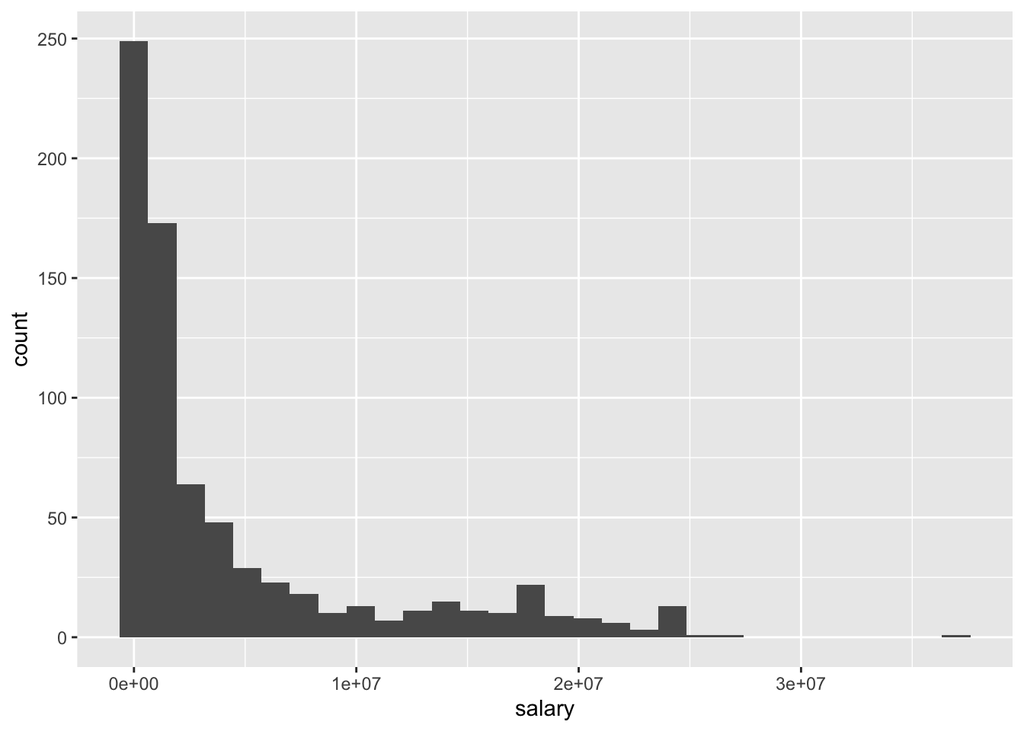

```r
ggplot(data = qb_sal, mapping = aes(x = salary)) +
  geom_histogram()
```

```r
options(scipen=999)
```

Here, I have filtered a histogram to only have Quarterback with salary on the x-axis.

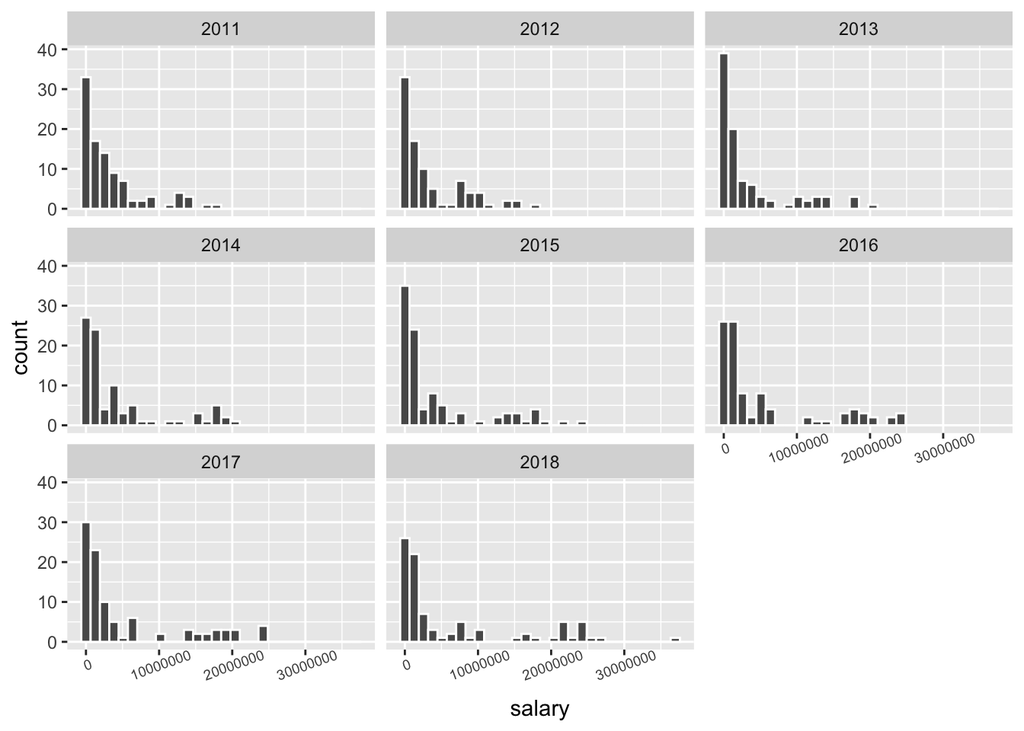

```r
ggplot(data = qb_sal, mapping = aes(x = salary)) +
  geom_histogram(color= "White") +
  facet_wrap(~ year) +
theme(axis.text.x = element_text(angle = 20, size = 7))
```

## **Question 4**

```r
summary_nfl_sal <- nfl_sal_tidy %>%
  group_by(position, year) %>%
  summarize(salary= mean(salary, na.rm = TRUE))
summary_nfl_sal
```

```
# A tibble: 80 × 3
# Groups:   position [10]
   position           year   salary
   <chr>             <dbl>    <dbl>
 1 Cornerback         2011 3037766.
 2 Cornerback         2012 3132916.
 3 Cornerback         2013 2901798.
 4 Cornerback         2014 3038278.
 5 Cornerback         2015 3758543.
 6 Cornerback         2016 4201470.
 7 Cornerback         2017 4125692.
 8 Cornerback         2018 4659704.
 9 Defensive Lineman  2011 4306995.
10 Defensive Lineman  2012 4693730.
# ℹ 70 more rows
```

Here, I used the group_by summarize combo to create a new data set for average salary for each position, each year.

## **Question 5**

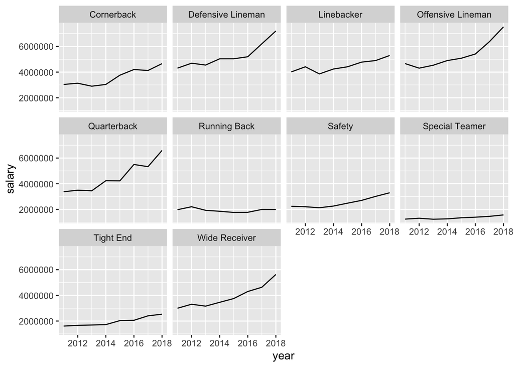

```r
ggplot(data = summary_nfl_sal, mapping = aes(x = year, y = salary)) + geom_line() + facet_wrap(~ position)
```

Looking at the data, I can see that the Special Teamer’s average salary across the years has stayed the same as the least paid position in the NFL with no real increase or decrease. The other thing I noticed is the recent increase in the average salaries of Defensive Lineman in the NFL. It stayed steady in the middle for a while, but within the last decade, the salary has increased much more.